# Returns to Education & the Gender Wage Gap — A Mincer Earnings Regression

Sai

June 25, 2026

## Overview

This report estimates a **Mincer earnings equation** — the workhorse model of labor economics relating log wages to education and experience — on 526 individuals from the 1976 Current Population Survey (CPS), collected by Henry Farber and distributed as the `wage1` dataset in Wooldridge’s *Introductory Econometrics: A Modern Approach*. It’s the econometrics counterpart to the rest of this portfolio: instead of describing data (the Excel/R sports and business projects) or querying it (the SQL projects), this project uses it to make and test statistical inferences — multiple regression, nested model comparisons, heteroskedasticity testing, and hand-derived robust standard errors — the analytical core of an economics degree.

The central question: **how much of the raw gender wage gap survives once you control for human capital (education, experience, tenure) and occupation/industry sorting?**

```r
d <- read.csv("wage1.csv")
cat("Observations:", nrow(d), " | Variables:", ncol(d), "\n")
```

```
## Observations: 526  | Variables: 25
```

```r
str(d[, c("wage","lwage","educ","exper","tenure","female","married","nonwhite")])
```

```
## 'data.frame':    526 obs. of  8 variables:
##  $ wage    : num  3.1 3.24 3 6 5.3 ...
##  $ lwage   : num  1.13 1.18 1.1 1.79 1.67 ...
##  $ educ    : int  11 12 11 8 12 16 18 12 12 17 ...
##  $ exper   : int  2 22 2 44 7 9 15 5 26 22 ...
##  $ tenure  : int  0 2 0 28 2 8 7 3 4 21 ...
##  $ female  : int  1 1 0 0 0 0 0 1 1 0 ...
##  $ married : int  0 1 0 1 1 1 0 0 0 1 ...
##  $ nonwhite: int  0 0 0 0 0 0 0 0 0 0 ...
```

**Data quality note (disclosed up front, not buried in a footnote):** the dataset’s own documentation flags that `exper` (total labor-market experience) and `tenure` (years with current employer) are self-reported and occasionally inconsistent — `tenure` cannot logically exceed `exper`, yet 16 of 526 observations (3%) violate that. Consistent with how Wooldridge distributes the data, I keep these rows rather than silently dropping them, and revisit this in the Limitations section.

## Exploratory Data Analysis

### Wage distribution

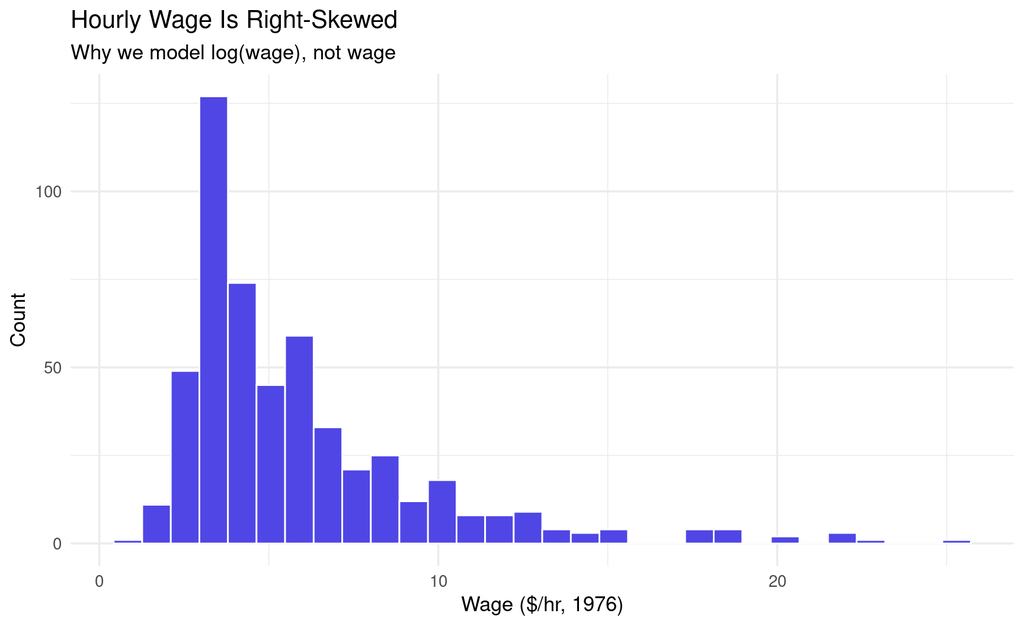

```r
ggplot(d, aes(x = wage)) +
  geom_histogram(bins = 30, fill = "#4f46e5", color = "white") +
  labs(title = "Hourly Wage Is Right-Skewed", subtitle = "Why we model log(wage), not wage",
       x = "Wage ($/hr, 1976)", y = "Count") +
  theme_minimal(base_size = 13)
```

Wages range from $0.53 to $24.9799995/hr with a mean of $5.9 but a median of only $4.65 — the right skew typical of earnings data, and the textbook reason to model `log(wage)` instead of the raw level: it both compresses the skew and lets coefficients be read as approximate percentage changes.

### Raw gender gap, before any controls

```r
gap_tbl <- d %>%
  group_by(female) %>%
  summarise(mean_wage = mean(wage), n = n()) %>%
  mutate(group = ifelse(female == 1, "Female", "Male"))
print(gap_tbl)
```

```
## # A tibble: 2 × 4
##   female mean_wage     n group
##    <int>     <dbl> <int> <chr>
## 1      0      7.10   274 Male
## 2      1      4.59   252 Female
```

```r
raw_gap_pct <- (gap_tbl$mean_wage[gap_tbl$female==0] - gap_tbl$mean_wage[gap_tbl$female==1]) /
  gap_tbl$mean_wage[gap_tbl$female==0] * 100
cat(sprintf("Raw gap: %.1f%%\n", raw_gap_pct))
```

```
## Raw gap: 35.4%
```

Men in this sample average $7.1/hr vs. $4.59/hr for women — a raw gap of **35.4%**. That number conflates two very different things: women in this sample may have less education/experience on average, *or* women may be paid less for the *same* human capital. The regressions below try to separate those two stories.

### Education and experience vs. log wage

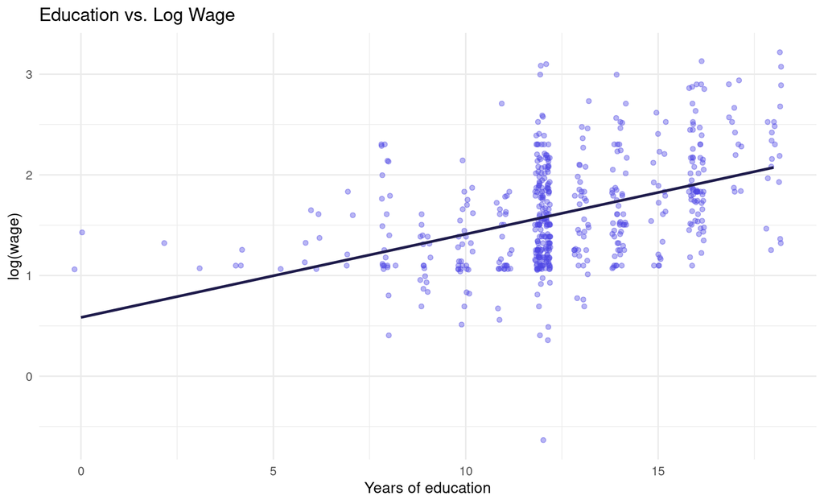

```r
p1 <- ggplot(d, aes(x = educ, y = lwage)) +
  geom_jitter(width = 0.2, alpha = 0.4, color = "#4f46e5") +
  geom_smooth(method = "lm", se = FALSE, color = "#1e1b4b") +
  labs(title = "Education vs. Log Wage", x = "Years of education", y = "log(wage)") +
  theme_minimal(base_size = 12)

p2 <- ggplot(d, aes(x = exper, y = lwage)) +
  geom_jitter(width = 0.3, alpha = 0.4, color = "#0ea5e9") +
  geom_smooth(method = "loess", se = FALSE, color = "#0c4a6e") +
  labs(title = "Experience vs. Log Wage", subtitle = "Loess curve shows diminishing returns",
       x = "Years of experience", y = "log(wage)") +
  theme_minimal(base_size = 12)

p1
```

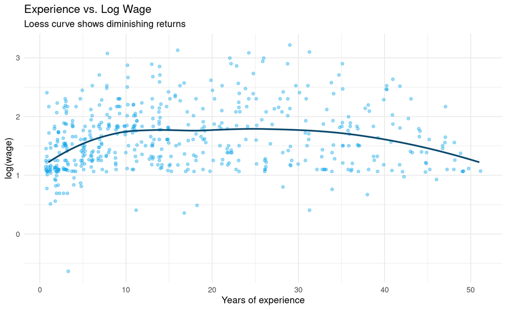

```r
p2
```

The education relationship looks roughly linear; the experience relationship visibly bends over — wages rise with experience but at a decreasing rate, which is why the models below include `exper` *and* `exper²`.

### Correlation among continuous predictors

```r
round(cor(d[, c("educ","exper","tenure","lwage")]), 3)
```

```
##          educ  exper tenure lwage
## educ    1.000 -0.300 -0.056 0.431
## exper  -0.300  1.000  0.499 0.111
## tenure -0.056  0.499  1.000 0.326
## lwage   0.431  0.111  0.326 1.000
```

`exper` and `tenure` correlate at 0.50 — expected, since people with more total labor-market experience also tend to have longer job tenure — but not high enough to cause serious multicollinearity problems in the models below.

## Model 1: Baseline Mincer Equation

$$\log(wage) = \beta_0 + \beta_1 educ + \beta_2 exper + \beta_3 exper^2 + \beta_4 tenure + u$$

```r
m1 <- lm(lwage ~ educ + exper + expersq + tenure, data = d)
summary(m1)
```

```
##
## Call:
## lm(formula = lwage ~ educ + exper + expersq + tenure, data = d)
##
## Residuals:
##      Min       1Q   Median       3Q      Max
## -1.97087 -0.26809 -0.03463  0.27663  1.28678
##
## Coefficients:
##               Estimate Std. Error t value Pr(>|t|)
## (Intercept)  0.1983445  0.1019556   1.945   0.0523 .
## educ         0.0853489  0.0071885  11.873  < 2e-16 ***
## exper        0.0328542  0.0051135   6.425 2.98e-10 ***
## expersq     -0.0006606  0.0001111  -5.945 5.08e-09 ***
## tenure       0.0208413  0.0030037   6.938 1.18e-11 ***
## ---
## Signif. codes:  0 '***' 0.001 '**' 0.01 '*' 0.05 '.' 0.1 ' ' 1
##
## Residual standard error: 0.427 on 521 degrees of freedom
## Multiple R-squared:  0.3595, Adjusted R-squared:  0.3545
## F-statistic: 73.09 on 4 and 521 DF,  p-value: < 2.2e-16
```

**Reading the coefficients (semi-log form, so each coefficient ≈ a % change in wage):**

- Each additional year of education is associated with a **8.53%** increase in wage, holding experience and tenure fixed (p < 0.001).
- Experience has a positive but *diminishing* return: the quadratic term is negative (-6.6^{-4}, p < 0.001), meaning the wage gain from one more year of experience shrinks as experience accumulates.
- Solving $-\beta_2 / (2\beta_3) = 0$ for the turning point:

```r
turning_pt <- -coef(m1)["exper"] / (2 * coef(m1)["expersq"])
cat(sprintf("Experience turning point: %.1f years\n", turning_pt))
```

```
## Experience turning point: 24.9 years
```

Predicted wage (holding education/tenure fixed) peaks around **24.9 years** of experience and is predicted to *decline* after that — a standard, textbook-consistent finding for cross-sectional wage data. - Tenure adds a further **2.08%** per year *with the same employer*, on top of general experience — consistent with firm-specific human capital / internal promotion effects. - The model explains **35.9%** of the variation in log wages (adj. R² = 0.355) — human capital alone leaves most of the variation in earnings unexplained, which motivates adding more controls below.

## Model 2: Adding Demographic Controls

```r
m2 <- lm(lwage ~ educ + exper + expersq + tenure + female + married + nonwhite, data = d)
summary(m2)
```

```
##
## Call:
## lm(formula = lwage ~ educ + exper + expersq + tenure + female +
##     married + nonwhite, data = d)
##
## Residuals:
##      Min       1Q   Median       3Q      Max
## -1.82063 -0.25863 -0.02226  0.24794  1.18007
##
## Coefficients:
##               Estimate Std. Error t value Pr(>|t|)
## (Intercept)  0.4201317  0.1003208   4.188 3.31e-05 ***
## educ         0.0796547  0.0068556  11.619  < 2e-16 ***
## exper        0.0301800  0.0052037   5.800 1.16e-08 ***
## expersq     -0.0006029  0.0001101  -5.476 6.79e-08 ***
## tenure       0.0160849  0.0028828   5.580 3.89e-08 ***
## female      -0.2914322  0.0363268  -8.023 6.97e-15 ***
## married      0.0554871  0.0410714   1.351    0.177
## nonwhite    -0.0186192  0.0581255  -0.320    0.749
## ---
## Signif. codes:  0 '***' 0.001 '**' 0.01 '*' 0.05 '.' 0.1 ' ' 1
##
## Residual standard error: 0.4018 on 518 degrees of freedom
## Multiple R-squared:  0.4362, Adjusted R-squared:  0.4286
## F-statistic: 57.26 on 7 and 518 DF,  p-value: < 2.2e-16
```

```r
female_pct_m2 <- (exp(coef(m2)["female"]) - 1) * 100
```

**Did adding this block of variables matter, jointly?**

```r
anova(m1, m2)
```

|  | Res.Df | RSS | Df | Sum of Sq | F | Pr(>F) |
| --- | --- | --- | --- | --- | --- | --- |
| 1 | 521 | 95.01105 | NA | NA | NA | NA |
| 2 | 518 | 83.62113 | 3 | 11.38992 | 23.51869 | 2.763554e-14 |

The F-test rejects the null that female/married/nonwhite jointly add nothing (p < 0.001) — even though two of the three are individually insignificant, the block is clearly informative as a whole (driven by `female`).

## Model 3: Adding Occupation & Region

```r
m3 <- lm(lwage ~ educ + exper + expersq + tenure + female + married + nonwhite +
            profocc + clerocc + servocc + south + west + northcen + smsa, data = d)
summary(m3)
```

```
##
## Call:
## lm(formula = lwage ~ educ + exper + expersq + tenure + female +
##     married + nonwhite + profocc + clerocc + servocc + south +
##     west + northcen + smsa, data = d)
##
## Residuals:
##     Min      1Q  Median      3Q     Max
## -1.7764 -0.2447 -0.0028  0.2331  1.1891
##
## Coefficients:
##               Estimate Std. Error t value Pr(>|t|)
## (Intercept)  0.6378812  0.1092256   5.840 9.29e-09 ***
## educ         0.0536110  0.0077297   6.936 1.23e-11 ***
## exper        0.0268306  0.0050253   5.339 1.41e-07 ***
## expersq     -0.0005471  0.0001061  -5.159 3.56e-07 ***
## tenure       0.0145896  0.0027532   5.299 1.73e-07 ***
## female      -0.2677264  0.0380573  -7.035 6.44e-12 ***
## married      0.0724332  0.0394494   1.836 0.066923 .
## nonwhite    -0.0068004  0.0558622  -0.122 0.903157
## profocc      0.1880875  0.0477213   3.941 9.23e-05 ***
## clerocc      0.0162941  0.0565263   0.288 0.773266
## servocc     -0.1599930  0.0558567  -2.864 0.004351 **
## south       -0.0573822  0.0464124  -1.236 0.216895
## west         0.0619658  0.0538543   1.151 0.250427
## northcen    -0.0508242  0.0485366  -1.047 0.295534
## smsa         0.1359358  0.0399173   3.405 0.000713 ***
## ---
## Signif. codes:  0 '***' 0.001 '**' 0.01 '*' 0.05 '.' 0.1 ' ' 1
##
## Residual standard error: 0.3817 on 511 degrees of freedom
## Multiple R-squared:  0.4982, Adjusted R-squared:  0.4844
## F-statistic: 36.23 on 14 and 511 DF,  p-value: < 2.2e-16
```

```r
female_pct_m3 <- (exp(coef(m3)["female"]) - 1) * 100
```

This is the most interesting result in the report. If the gender wage gap were mostly a story of women sorting into lower-paying occupations or regions, controlling for occupation and region should shrink the `female` coefficient substantially. It barely moves: from **25.3%** in Model 2 to **23.5%** here. Occupational and regional sorting explain only a small slice of the gap in this sample — most of it persists *within* occupation and region.

The occupation/region controls themselves are informative on their own terms: professional occupations carry a **+18.8%** premium and service occupations a **-16%** penalty (both p < 0.01) relative to the baseline occupation category, and living in a metro area (`smsa`) is worth **+13.6%** (p < 0.001). Clerical occupation and the regional dummies (south/west/northcen) are not statistically significant here.

```r
anova(m2, m3)
```

|  | Res.Df | RSS | Df | Sum of Sq | F | Pr(>F) |
| --- | --- | --- | --- | --- | --- | --- |
| 1 | 518 | 83.62113 | NA | NA | NA | NA |
| 2 | 511 | 74.43761 | 7 | 9.183511 | 9.00615 | 1.705355e-10 |

The occupation/region block is also jointly significant (p < 0.001) — it improves the model’s fit, just not by reshaping the gender coefficient much.

### Model comparison summary

```r
comp <- data.frame(
  Model = c("1: Human capital", "2: + demographics", "3: + occupation/region"),
  R2 = c(summary(m1)$r.squared, summary(m2)$r.squared, summary(m3)$r.squared),
  Adj_R2 = c(summary(m1)$adj.r.squared, summary(m2)$adj.r.squared, summary(m3)$adj.r.squared),
  Female_coef_pct = c(NA, round(female_pct_m2,1), round(female_pct_m3,1))
)
comp$R2 <- round(comp$R2, 3)
comp$Adj_R2 <- round(comp$Adj_R2, 3)
comp
```

| Model | R2 | Adj_R2 | Female_coef_pct |
| --- | --- | --- | --- |
| 1: Human capital | 0.359 | 0.355 | NA |
| 2: + demographics | 0.436 | 0.429 | -25.3 |
| 3: + occupation/region | 0.498 | 0.484 | -23.5 |

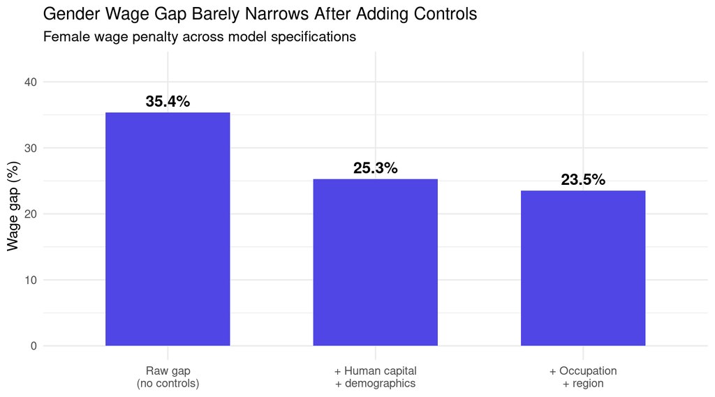

```r
gap_df <- data.frame(
  stage = factor(c("Raw gap\n(no controls)","+ Human capital\n+ demographics","+ Occupation\n+ region"),
                 levels = c("Raw gap\n(no controls)","+ Human capital\n+ demographics","+ Occupation\n+ region")),
  gap = c(raw_gap_pct, abs(female_pct_m2), abs(female_pct_m3))
)
ggplot(gap_df, aes(x = stage, y = gap)) +
  geom_col(fill = "#4f46e5", width = 0.6) +
  geom_text(aes(label = sprintf("%.1f%%", gap)), vjust = -0.5, size = 5, fontface = "bold") +
  labs(title = "Gender Wage Gap Barely Narrows After Adding Controls",
       subtitle = "Female wage penalty across model specifications", x = NULL, y = "Wage gap (%)") +
  ylim(0, max(gap_df$gap) * 1.2) +
  theme_minimal(base_size = 13)
```

## Heteroskedasticity: Does It Matter Here?

OLS standard errors assume constant error variance (homoskedasticity). Earnings data usually violates this in *levels* — high earners have more dispersed pay than low earners. A Breusch-Pagan test on the squared residuals confirms it:

```r
m3_level <- lm(wage ~ educ + exper + expersq + tenure + female + married + nonwhite +
                  profocc + clerocc + servocc + south + west + northcen + smsa, data = d)
u_level <- resid(m3_level)
bp_level <- lm(u_level^2 ~ educ + exper + expersq + tenure + female + married + nonwhite +
                  profocc + clerocc + servocc + south + west + northcen + smsa, data = d)
n <- nrow(d); k_bp <- length(coef(bp_level)) - 1
bp_stat_level <- n * summary(bp_level)$r.squared
bp_p_level <- 1 - pchisq(bp_stat_level, df = k_bp)
cat(sprintf("Levels model (wage ~ ...): BP stat = %.2f, df = %d, p = %.2e\n", bp_stat_level, k_bp, bp_p_level))
```

```
## Levels model (wage ~ ...): BP stat = 63.86, df = 14, p = 2.44e-08
```

Strongly significant (p 2.44e-08) — exactly why labor economists model `log(wage)`, not `wage`, in the first place. Re-running the same test on the **log** model:

```r
u3 <- resid(m3)
bp_log <- lm(u3^2 ~ educ + exper + expersq + tenure + female + married + nonwhite +
                  profocc + clerocc + servocc + south + west + northcen + smsa, data = d)
bp_stat_log <- n * summary(bp_log)$r.squared
bp_p_log <- 1 - pchisq(bp_stat_log, df = k_bp)
cat(sprintf("Log model (lwage ~ ...): BP stat = %.2f, df = %d, p = %.3f\n", bp_stat_log, k_bp, bp_p_log))
```

```
## Log model (lwage ~ ...): BP stat = 16.47, df = 14, p = 0.285
```

The log transform does most of the work: heteroskedasticity is no longer statistically significant at conventional levels (p = 0.285). There’s a mild residual pattern in the tails though:

```r
ft <- fitted(m3)
grp <- cut(ft, quantile(ft, c(0, 1/3, 2/3, 1)), include.lowest = TRUE, labels = c("Low","Mid","High"))
tapply(u3, grp, sd)
```

```
##       Low       Mid      High
## 0.3487523 0.3532644 0.4188321
```

Residual spread is noticeably wider in the top fitted-value tercile, so as a robustness check (best practice regardless of the test result) I compute **heteroskedasticity-robust (White/HC1) standard errors by hand** — no `sandwich`/`lmtest` package, just the sandwich formula directly:

$$\widehat{Var}_{HC1}(\hat\beta) = (X'X)^{-1} X' \,\text{diag}(\hat u_i^2)\, X (X'X)^{-1} \cdot \frac{n}{n-k}$$

```r
X <- model.matrix(m3)
u <- resid(m3)
n <- nrow(X); k <- ncol(X)
XtX_inv <- solve(t(X) %*% X)
meat <- t(X) %*% diag(u^2) %*% X * (n / (n - k))
vcov_hc1 <- XtX_inv %*% meat %*% XtX_inv
se_robust <- sqrt(diag(vcov_hc1))
se_classical <- sqrt(diag(vcov(m3)))

se_compare <- data.frame(
  Coefficient = names(coef(m3)),
  Estimate = round(coef(m3), 4),
  SE_classical = round(se_classical, 4),
  SE_robust = round(se_robust, 4),
  p_robust = round(2 * pt(-abs(coef(m3) / se_robust), df = n - k), 4)
)
se_compare
```

|  | Coefficient | Estimate | SE_classical | SE_robust | p_robust |
| --- | --- | --- | --- | --- | --- |
| (Intercept) | (Intercept) | 0.6379 | 0.1092 | 0.1130 | 0.0000 |
| educ | educ | 0.0536 | 0.0077 | 0.0083 | 0.0000 |
| exper | exper | 0.0268 | 0.0050 | 0.0047 | 0.0000 |
| expersq | expersq | -0.0005 | 0.0001 | 0.0001 | 0.0000 |
| tenure | tenure | 0.0146 | 0.0028 | 0.0033 | 0.0000 |
| female | female | -0.2677 | 0.0381 | 0.0383 | 0.0000 |
| married | married | 0.0724 | 0.0394 | 0.0409 | 0.0771 |
| nonwhite | nonwhite | -0.0068 | 0.0559 | 0.0588 | 0.9080 |
| profocc | profocc | 0.1881 | 0.0477 | 0.0479 | 0.0001 |
| clerocc | clerocc | 0.0163 | 0.0565 | 0.0532 | 0.7594 |

[output cut: 5 more lines]

The robust and classical standard errors are close for almost every coefficient — `tenure`’s SE rises the most (0.0028 → 0.0033, about 1.21x) — but no significance conclusion at the 5% level flips either direction. The mild heteroskedasticity detected above doesn’t change the substantive findings; it’s reported because checking is the correct intermediate-econometrics move, not because it overturns anything.

## Residual Diagnostics

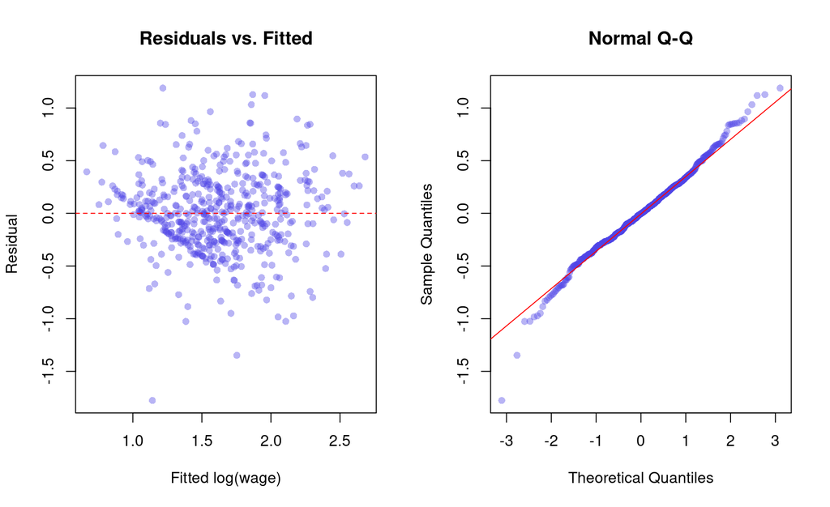

```r
par(mfrow = c(1, 2))
plot(fitted(m3), resid(m3), pch = 16, col = rgb(0.31, 0.27, 0.9, 0.4),
     main = "Residuals vs. Fitted", xlab = "Fitted log(wage)", ylab = "Residual")
abline(h = 0, col = "red", lty = 2)
qqnorm(resid(m3), pch = 16, col = rgb(0.31, 0.27, 0.9, 0.4), main = "Normal Q-Q")
qqline(resid(m3), col = "red")
```

Residuals are centered on zero with a slight funnel/widening at higher fitted values (consistent with the tercile check above) and roughly normal in the middle of the distribution with some departure in the tails — typical for wage data, and not severe enough to invalidate the conclusions, especially since the robust SEs confirm the same inferences.

## Limitations

This is intermediate applied econometrics, not a causal study, and I want to be specific about why:

**Omitted ability bias.** The biggest threat to interpreting `educ`’s coefficient as a *causal* return to schooling is unobserved ability: people with more innate ability or motivation likely get more education *and* earn more for reasons unrelated to schooling itself, which biases the education coefficient upward. The standard fix — instrumenting education with something correlated with schooling but not ability (e.g., compulsory schooling laws, distance to college) — isn’t implemented here; this report estimates an association, not a causal effect.

**External validity.** This is 1976 U.S. CPS data. Wage *levels* are obviously irrelevant today, and the labor market has changed enough (composition of occupations, female labor force participation, returns to specific majors) that even the relative patterns shouldn’t be assumed to hold in 2026. The methodology generalizes; the numbers don’t.

**Self-reported, possibly mismeasured data.** As flagged at the top, 16 of 526 observations have `tenure > exper`, a logical impossibility, indicating measurement error in at least one of those two variables for a small share of the sample. Measurement error in regressors generally biases coefficients toward zero (attenuation bias) rather than away from it.

**No interaction effects tested.** A natural extension — does the return to education differ by gender, or does the experience penalty/premium differ by occupation — would require interaction terms not estimated here.

## Conclusion

Three nested regressions on 1976 CPS data show: education carries a statistically robust return (~8.5% per year in the simplest specification), experience has diminishing returns peaking around 25 years, and a gender wage gap of roughly 25–23% persists even after controlling for education, experience, tenure, marital status, occupation, and region — meaning the gap is not primarily explained by women and men sorting into different jobs or having different qualifications, at least along the dimensions this dataset measures. Heteroskedasticity-robust standard errors were derived by hand and confirm the findings aren’t an artifact of a violated OLS assumption. The honest caveat is that none of this is causal without an identification strategy for education and without richer controls for productivity-relevant traits this survey didn’t collect.